# Datasets

Richard White

2019-08-29

# Dev Installation

If you want to install the dev version, run `usethis::edit_r_profile()` to edit your `.Rprofile`. Then write in:

```
options(repos=structure(c(
  FHI="https://folkehelseinstituttet.github.io/drat/",
  CRAN="https://cran.rstudio.com"
)))
```

Save the file and restart R. This will allow you to install `fhidata` from the FHI registry instead of CRAN.

# Population Datasets

We conveniently package population data taken from Statistics Norway. This data is licensed under the Norwegian Licence for Open Government Data (NLOD) 2.0.

## norway_population_current

```
#>         year location_code    level age   pop imputed
#>      1: 1846        norway national   0 36372   FALSE
#>      2: 1846        norway national   1 32831   FALSE
#>      3: 1846        norway national   2 33493   FALSE
#>      4: 1846        norway national   3 34901   FALSE
#>      5: 1846        norway national   4 32719   FALSE
#>     ---
#> 765210: 2021        norway national 103   100    TRUE
#> 765211: 2021        norway national 104    53    TRUE
#> 765212: 2021        norway national 104    53    TRUE
#> 765213: 2021        norway national 105    68    TRUE
#> 765214: 2021        norway national 105    68    TRUE
```

## norway_population_original

```
#>         year location_code    level age   pop imputed
#>      1: 1846        norway national   0 36372   FALSE
#>      2: 1846        norway national   1 32831   FALSE
#>      3: 1846        norway national   2 33493   FALSE
#>      4: 1846        norway national   3 34901   FALSE
#>      5: 1846        norway national   4 32719   FALSE
#>     ---
#> 903964: 2021        norway national 103   100    TRUE
#> 903965: 2021        norway national 104    53    TRUE
#> 903966: 2021        norway national 104    53    TRUE
#> 903967: 2021        norway national 105    68    TRUE
#> 903968: 2021        norway national 105    68    TRUE
```

# Vaccine datasets

## norway_childhood_vax

We conveniently package vaccine coverage data taken from “Kommunehelsa statistikkbank”. This data was last updated on 2019-04-09. This dataset contains national/county/municipality level (5 year average) vaccination coverage rates for 16 year olds for the childhood vaccination program (diphtheria, hpv, measles, mumps, poliomyelitis, pertussis, rubella, tetanus). Municipalities are updated for the 2019 redistricting.

```
#>        year location_code age        vax proportion imputed
#>     1: 2011      county01  16 diphtheria  0.8824899   FALSE
#>     2: 2011      county02  16 diphtheria  0.9250157   FALSE
#>     3: 2011      county03  16 diphtheria  0.8923676   FALSE
#>     4: 2011      county04  16 diphtheria  0.9203255   FALSE
#>     5: 2011      county05  16 diphtheria  0.9418884   FALSE
#>    ---
#> 17214: 2016   municip5052  16    tetanus  0.6250000   FALSE
#> 17215: 2016   municip5053  16    tetanus  0.9411765   FALSE
#> 17216: 2016   municip5054  16    tetanus  0.9001447   FALSE
#> 17217: 2016   municip5061  16    tetanus  0.9151873    TRUE
#> 17218: 2016        norway  16    tetanus  0.9151873   FALSE
```

# Location Codes/Names Datasets

We provide location names and location codes in multiple formats.

## norway_locations_long_current

This dataset contains national/county/municipality codes and names. The counties and municipalities are updated for the current redistricting.

```
#>      location_code      location_name
#>   1:        norway             Norway
#>   2:         norge              Norge
#>   3:   municip0101             Halden
#>   4:   municip0104               Moss
#>   5:   municip0105          Sarpsborg
#>  ---
#> 438:      county15    Møre-og-Romsdal
#> 439:      county18           Nordland
#> 440:      county19              Troms
#> 441:      county20 Finnmark-Finnmarku
#> 442:      county50          Trøndelag
```

## norway_locations_long_original

This dataset contains national/county/municipality codes and names. The counties and municipalities are not updated for the current redistricting.

```
#>      location_code      location_name
#>   1:        norway             Norway
#>   2:         norge              Norge
#>   3:   municip0101             Halden
#>   4:   municip0104               Moss
#>   5:   municip0105          Sarpsborg
#>  ---
#> 504:      county17     Nord-Trøndelag
#> 505:      county18           Nordland
#> 506:      county19              Troms
#> 507:      county20 Finnmark-Finnmarku
#> 508:      county50          Trøndelag
```

## norway_locations_current

This dataset contains county codes/names and municipality codes/names for each municipality. The counties and municipalities are updated for the current redistricting.

```
#>      municip_code municip_name county_code county_name
#>   1:  municip0101       Halden    county01     Østfold
#>   2:  municip0104         Moss    county01     Østfold
#>   3:  municip0105    Sarpsborg    county01     Østfold
#>   4:  municip0106  Fredrikstad    county01     Østfold
#>   5:  municip0111       Hvaler    county01     Østfold
#>  ---
#> 418:  municip5054  Indre-Fosen    county50   Trøndelag
#> 419:  municip0715  Holmestrand    county07    Vestfold
#> 420:  municip0729       Færder    county07    Vestfold
#> 421:  municip0712       Larvik    county07    Vestfold
#> 422:  municip5061       Rindal    county50   Trøndelag
```

## norway_locations_original

This dataset contains county codes/names and municipality codes/names for each municipality. The counties and municipalities are not updated for the current redistricting.

```
#>      municip_code municip_name county_code county_name
#>   1:  municip0101       Halden    county01     Østfold
#>   2:  municip0104         Moss    county01     Østfold
#>   3:  municip0105    Sarpsborg    county01     Østfold
#>   4:  municip0106  Fredrikstad    county01     Østfold
#>   5:  municip0111       Hvaler    county01     Østfold
#>  ---
#> 482:  municip5054  Indre-Fosen    county50   Trøndelag
#> 483:  municip0715  Holmestrand    county07    Vestfold
#> 484:  municip0729       Færder    county07    Vestfold
#> 485:  municip0712       Larvik    county07    Vestfold
#> 486:  municip5061       Rindal    county50   Trøndelag
```

## norway_municip_merging

This dataset is used to transfer “original” municipality level datasets to the current redistricting.

```
#>       municip_code_current municip_code_original year municip_name
#>    1:          municip0101           municip0101 2006       Halden
#>    2:          municip0101           municip0101 2007       Halden
#>    3:          municip0101           municip0101 2008       Halden
#>    4:          municip0101           municip0101 2009       Halden
#>    5:          municip0101           municip0101 2010       Halden
#>   ---
#> 6833:          municip5061           municip1567 2017       Rindal
#> 6834:          municip5061           municip1567 2018       Rindal
#> 6835:          municip5061           municip5061 2019       Rindal
#> 6836:          municip5061           municip5061 2020       Rindal
#> 6837:          municip5061           municip5061 2021       Rindal
#>       county_code county_name region_code    region_name
#>    1:    county01     Østfold     region5 Eastern Norway
#>    2:    county01     Østfold     region5 Eastern Norway
#>    3:    county01     Østfold     region5 Eastern Norway
#>    4:    county01     Østfold     region5 Eastern Norway
#>    5:    county01     Østfold     region5 Eastern Norway
#>   ---
#> 6833:    county50   Trøndelag     region2      Trøndelag
#> 6834:    county50   Trøndelag     region2      Trøndelag
#> 6835:    county50   Trøndelag     region2      Trøndelag
#> 6836:    county50   Trøndelag     region2      Trøndelag
#> 6837:    county50   Trøndelag     region2      Trøndelag
```

# English to Norwegian Datasets

We provide some datasets for easy Norwegian to English translations.

## countries_nb_to_en

```
#>               nb          en
#>   1: Afghanistan Afghanistan
#>   2:     Albania     Albania
#>   3:     Algerie     Algeria
#>   4:     Andorra     Andorra
#>   5:      Angola      Angola
#>  ---
#> 144:  Usbekistan  Uzbekistan
#> 145:   Venezuela   Venezuela
#> 146:     Vietnam     Vietnam
#> 147:      Zambia      Zambia
#> 148:    Zimbabwe    Zimbabwe
```

# Maps and Map Datasets

We conveniently package map datasets for Norway (taken from Geonorge) that can be used in ggplot2 without needing any geo libraries. This data is licensed under Creative Commons 0.

## County Maps (norway_map_counties)

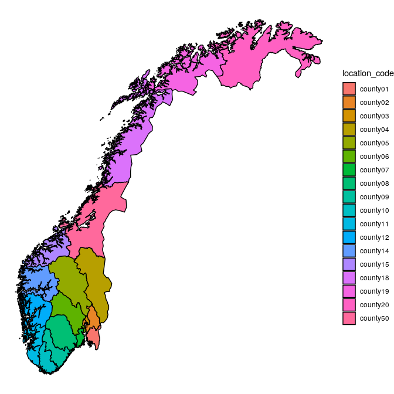

```r
library(ggplot2)
library(data.table)

pd <- fhidata::norway_map_counties

q <- ggplot()
q <- q + geom_polygon(data = pd, aes( x = long, y = lat, group = group, fill=location_code), color="black")
q <- q + theme_void()
q <- q + coord_quickmap()
q
```

## Municipality Maps (norway_map_municips)

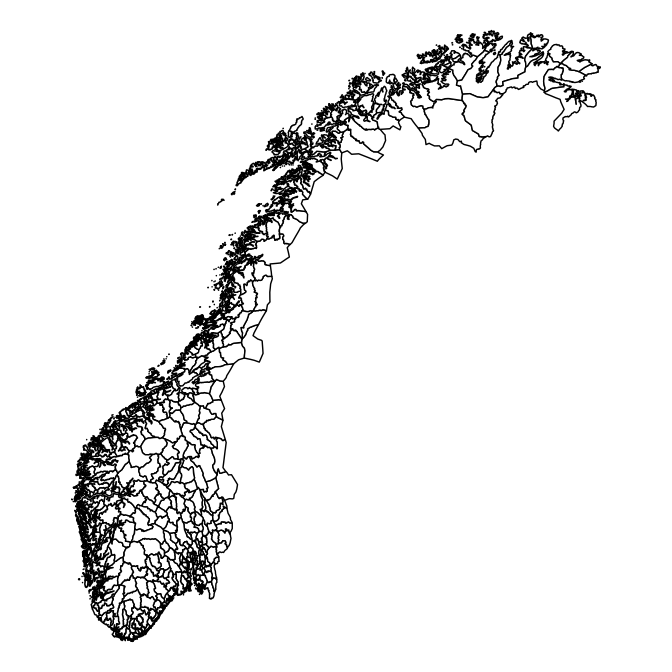

```r
library(ggplot2)
library(data.table)

pd <- fhidata::norway_map_municips

q <- ggplot()
q <- q + geom_polygon(data = pd, aes( x = long, y = lat, group = group), color="black", fill="white")
q <- q + theme_void()
q <- q + coord_quickmap()
q
```